# R Notes 1-2 – Sampling Distributions

### Overview

This document will demonstrate the relationship between the different kinds of distributions we have now (population, sample and sampling distribution). This will involve learning to take random samples and conduct mini simulations to build a sampling distribution. We will demonstrate this for several of distributions / statistics.

### Sampling distribution concept: Normal

Sampling distributions are the basis of the statistical inference we will learn (confidence intervals and hypothesis tests). So it will be important to conceptually understand what a sampling distribution is. To help with this, we are going to build (simulate) one! We are going to demonstrate this using the Normal distribution first.

With the addition of sampling distributions, we now have three different types of distributions that we need to understand.

**1) Population distribution**

- This is all the distributions we studied in MATH 320 (all the plots made in the ‘Probability.R’ file we are thinking of as population distributions).
- These are theoretical distributions that we are assuming to be true.

Let $X \sim \text{Normal}\,(\mu = 50, \sigma = 10)$.

First we will initialize the parameters to reuse in the rest of the code.

```r
# initialize parameters
mu <- 50
sigma <- 10
```

Now we can plot the population distribution.

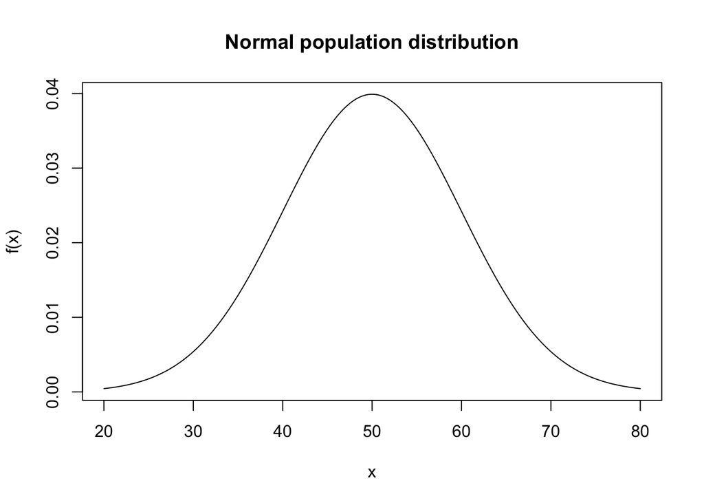

```r
# visualize population distribution
x <- seq(from = mu - 3 * sigma, to = mu + 3 * sigma, by = 0.01)
plot(x = x, y = dnorm(x, mean = mu, sd = sigma), type = "l", xlab = "x", ylab = "f(x)", main = "Normal population distribution")
```

**2) Sample (data) distribution**

- This is the result of randomly sampling from the population distribution (i.e. collecting data).
- When simulating a random sample, we are essentially just generating $x$ values whose probabilities of being selected follow the population distribution.

Lets take a random sample of size $n = 30$, which means $X \overset{iid}\sim \text{Normal}\,(\mu = 50, \sigma = 10)$. Use `rnorm()` to randomly generating observations from a normal distribution.

```r
# initialize sample size and generate random sample
n <- 30
data_sample <- rnorm(n = n, mean = mu, sd = sigma)
data_sample
```

```
 [1] 48.87578 50.14952 50.04407 50.75774 59.24456 68.02517 50.01873 40.86572
 [9] 44.92340 49.32929 68.23068 41.95129 74.85090 61.90378 58.98155 50.39292
[17] 61.12556 42.06545 52.74527 57.83612 72.48652 52.16585 59.65869 50.87384
[25] 37.69425 42.30296 64.79651 52.31487 45.63077 49.69894
```

We can plot the sample (data) distribution with a histogram by using `hist()`.

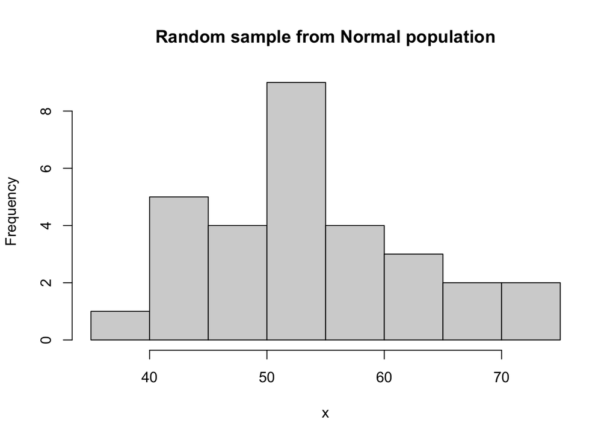

```r
# visualize sample (data) distribution
hist(x = data_sample, xlab = "x", main = "Random sample from Normal population")
```

Every random sample that we take will look slightly different of course because of the randomness. But all of the sample distributions should match the properties of the population distribution they were drawn from. This means $\bar{X} \approx \mu$, $S \approx \sigma$, and roughly matches the shape. To check the summary statistics, use `mean()` and `sd()`. With larger sample sizes, the sample values will on average be closer to the population values.

```r
# check summary statistics for our random sample
mean(data_sample)
```

```
[1] 53.66469
```

```r
mu
```

```
[1] 50
```

```r
sd(data_sample)
```

```
[1] 9.59604
```

```r
sigma
```

```
[1] 10
```

To compare the shapes, we can add the population distribution curve to the sample distribution histogram.

First we need to plot the histogram like before, except specify `freq = FALSE` to make the y-axis relative frequency (probability) rather than frequency (count). Then use `lines()` to overlay the density curve.

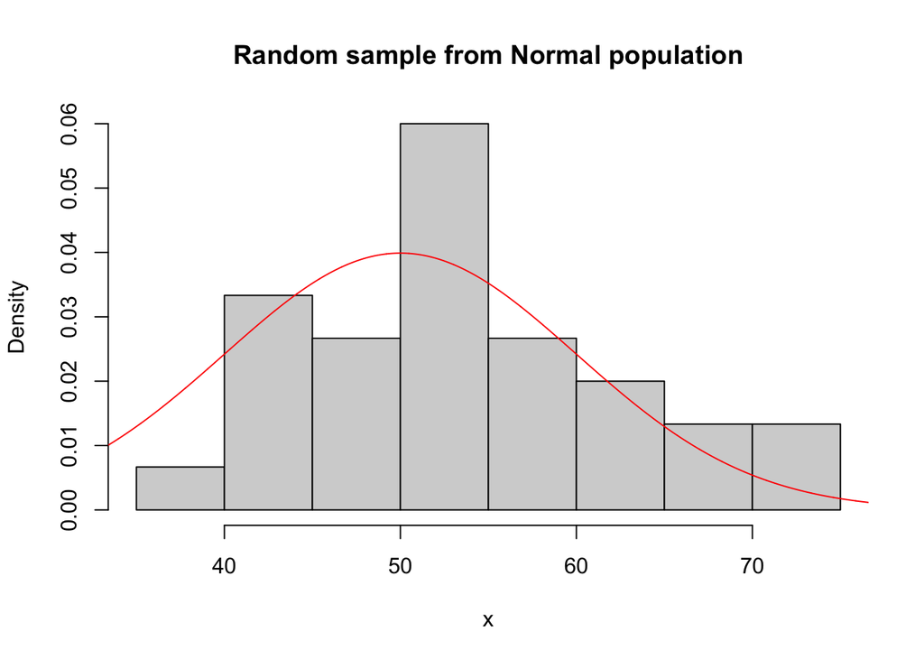

```r
# plot relative frequency histogram and add population density curve
hist(x = data_sample, freq = FALSE, xlab = "x", main = "Random sample from Normal population")
lines(x = x, y = dnorm(x, mean = mu, sd = sigma), col = "red")
```

**3) SamplING distribution**

- This is also a theoretical distribution of a statistic (like sample mean, $\bar{X}$) that occasionally ends up following a familiar distribution (depends on what population we start with).
- But it can easily be simulated to get a really good approximation of the shape and summary statistics.

Now lets build up to a sampling distribution.

We already have a random sample of data, so lets record the sample mean.

```r
# record the sample mean
x_bar <- c()
x_bar[1] <- mean(data_sample)
```

We have now started a vector (distribution) of sample means, all we need to do is add a bunch more sample means to it. So we need to generate several random samples of data, calculate and record their respective sample means. To repeat calculations / operations many times, we can use a `for` loop.

```r
# initialize our holding vector again
x_bar <- c()
for (i in 1:20) {

  # i is the index, the for loop runs for each value of the index

  # generate data
  data_sample <- rnorm(n = n, mean = mu, sd = sigma)

  # record sample mean
  x_bar[i] <- mean(data_sample)

  # once both of these are done, the for loop goes to the next index value and performs the loop again
}
```

Now we have $i = 20$ sample means calculated from 20 random samples of data. Lets plot them to see the beginnings of the sampling distribution.

```r
# show sample mean values
x_bar
```

```
 [1] 49.24681 50.90845 48.97659 50.51217 51.01939 52.42466 51.79923 51.64964
 [9] 51.77193 50.08190 48.58526 52.48046 49.64601 49.15878 52.22386 47.03738
[17] 50.60057 52.94095 47.29008 49.84097
```

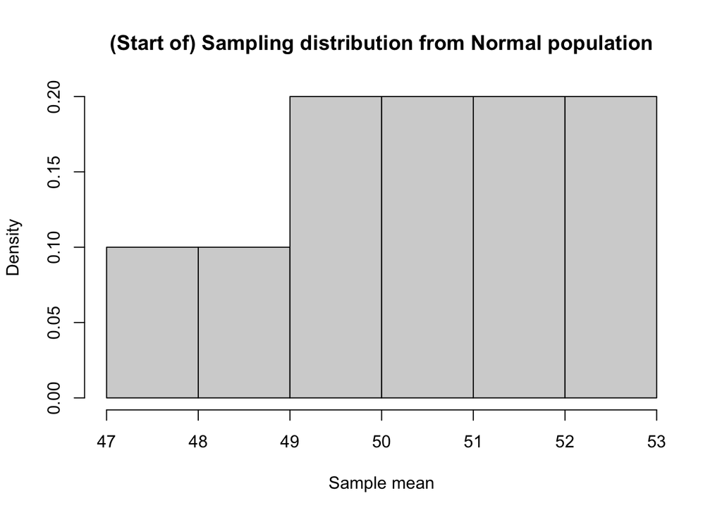

```r
# plot sample means
hist(x = x_bar, freq = FALSE, xlab = "Sample mean", main = "(Start of) Sampling distribution from Normal population")
```

Lets continue building the sampling distribution. Theoretically the sampling distribution is the distribution of ALL POSSIBLE sample means. For a simulation, this just means calculate a very large number of them. So lets repeat the for loop, but for a very large $i$.

```r
# simulate 100,000 samples and calculate mean
x_bar <- c()
for (i in 1:100000) {

  # generate data
  data_sample <- rnorm(n = n, mean = mu, sd = sigma)

  # record sample mean
  x_bar[i] <- mean(data_sample)
}
```

Now lets plot the sampling distribution of $\bar{X}$. We will see that it is perfectly centered at the population mean, and also much less variable than the sample distribution (much smaller spread). To verify that, we can add the population mean to the plot for reference. Use `abline(v = )` to add a vertical $x = $ line.

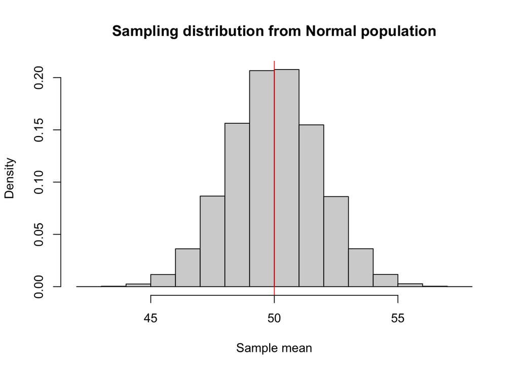

```r
# plot sample means and add population mean reference line
hist(x = x_bar, freq = FALSE, xlab = "Sample mean", main = "Sampling distribution from Normal population")
abline(v = mu, col = "red")
```

Lets look at the summary statistics for this new distribution and compare them to the population values.

Because we are studying the sample mean, the results should match the theorem we learned that $E(\bar{X}) = \mu$ and $V(\bar{X}) = \sigma^2 / n$. This is true regardless of population distribution.

```r
# compare summary statistics of sampling distribution to theoretical results in terms of the population parameters
mean(x_bar)
```

```
[1] 49.99892
```

```r
mu
```

```
[1] 50
```

```r
var(x_bar)
```

```
[1] 3.354654
```

```r
sigma^2 / n
```

```
[1] 3.333333
```

Then because we started with a normal distribution, we actually know exactly what distribution $\bar{X}$ follows from another theorem. If $X_i \overset{iid}\sim \text{Normal}\,(\mu = 50, \sigma = 10)$, then $\bar{X} \sim \text{Normal}\,(\mu, \sigma^2 / n)$. Lets verify this by adding the density curve to the histogram of sample means, it should line up perfectly.

To generalize our specification of `x` which we need for `lines()`, we can generate a sequence of values that are three standard deviations `sd(x_bar)` from the center of the simulated sampling distribution `mean(x_bar)` in either direction. For most distributions, this will cover the range of values we need.

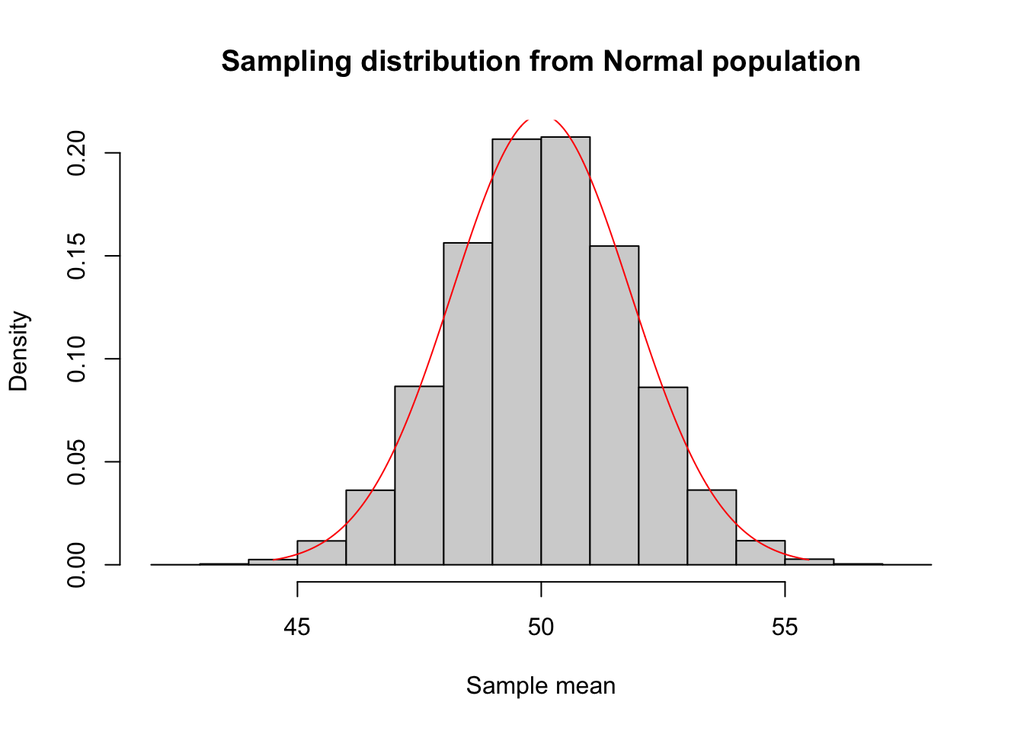

```r
# add theoretical density curve to histogram of sampling distribution
hist(x = x_bar, freq = FALSE, xlab = "Sample mean", main = "Sampling distribution from Normal population")
x <- seq(from = mean(x_bar) - 3 * sd(x_bar), to = mean(x_bar) + 3 * sd(x_bar), by = 0.01)
lines(x = x, y = dnorm(x, mean = mu, sd = sigma/sqrt(n)), col = "red")
```

We can build sampling distributions for any statistic So lets repeat the process above for the sample variance $S^2$ when drawing from a normal population. All we have to do different is calculate a different sample statistic inside the for loop for each of the generated samples.

```r
# simulate sampling distribution for sample variance
s2 <- c()
for (i in 1:100000) {

  # generate data
  data_sample <- rnorm(n = n, mean = mu, sd = sigma)

  # record sample mean
  s2[i] <- var(data_sample)

}
```

To show the first few observations, we can use `head()`.

```r
# display first 10 values
head(s2)
```

```
[1] 105.05911  62.07189  82.87647  86.81329  78.99765 112.96940
```

Now we can plot this new sampling distribution and add the population variance to the plot for reference as well.

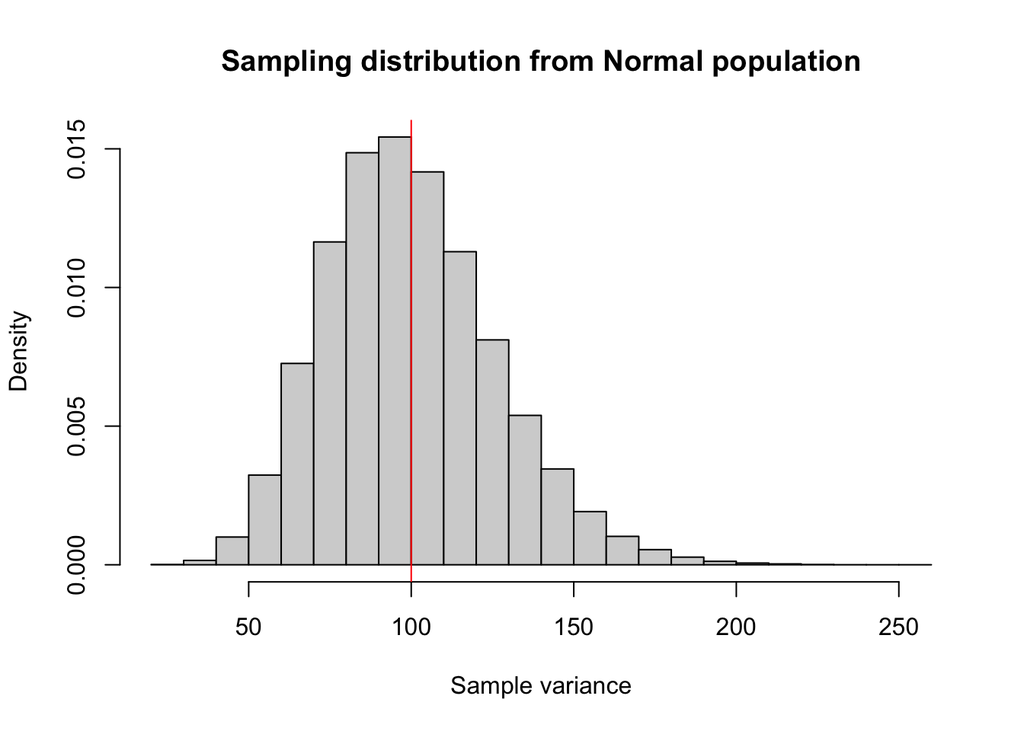

```r
# plot the sampling distribution of S^2 and add population value for reference
hist(x = s2, freq = FALSE, xlab = "Sample variance", main = "Sampling distribution from Normal population")
abline(v = sigma^2, col = "red")
```

We know from a theorem that $E(S^2) = \sigma^2$. So lets check the estimated mean of the sampling distribution and compare it to $\sigma^2$.

```r
# compare sampling distribution center to the population value
mean(s2)
```

```
[1] 99.90854
```

```r
sigma^2
```

```
[1] 100
```

We don’t know what distribution $S^2$ follows by itself, but we can modify it to match the theorem we have: $\frac{n - 1}{\sigma^2} S^2 \sim \chi^2 (n-1)$.

```r
# calculate and display modified sample variances
s2_modified <- (n - 1) * s2 / sigma^2
head(s2_modified)
```

```
[1] 30.46714 18.00085 24.03418 25.17585 22.90932 32.76113
```

Now we can plot this and compare it to the theoretical density it should follow. For the specification of $x$, we know $\chi^2$ is a special-case gamma density, which means it is right-skewed. So lets go to 4 standard deviations above to ensure our line has the correct range.

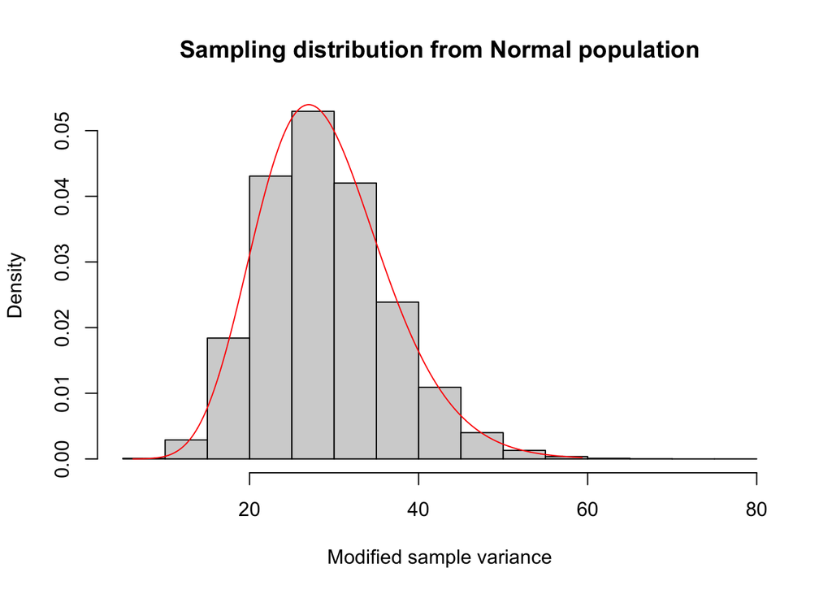

```r
# plot modified sample variances and add theoretical density curve
hist(x = s2_modified, freq = FALSE, xlab = "Modified sample variance", main = "Sampling distribution from Normal population")
x <- seq(from = mean(s2_modified) - 3 * sd(s2_modified), to = mean(s2_modified) + 4 * sd(s2_modified), by = 0.01)
lines(x = x, y = dchisq(x, df = n - 1), col = "red")
```

### Exponential sample means

Goal is simulate the sampling distribution for the sample mean based on an exponential distribution.

To generate a random sample from the exponential distribution, use `rexp()`, where `rate = lambda`.

```r
# initialize necessary items
# -> parameter
# -> sample size
# -> holding vector for sample means
lambda <- 50
n <- 20
x_bar <- c()

# simulate sampling distribution for sample mean
for (i in 1:100000) {

  # generate data
  data_sample <- rexp(n = n, rate = lambda)

  # record sample mean
  x_bar[i] <- mean(data_sample)
}

# display values
head(x_bar)
```

```
[1] 0.01585060 0.02475739 0.02491829 0.01468382 0.02172151 0.01882657
```

Compare the summary statistics to the populations values (what they should be). For exponential, $\mu = E(X) = 1 / \lambda$ and $\sigma^2 = V(X) = 1 / \lambda^2$. Then apply the $\bar{X}$ theorem.

```r
# compare summary statistics to the correct population values
mean(x_bar)
```

```
[1] 0.02001841
```

```r
1 / lambda
```

```
[1] 0.02
```

```r
var(x_bar)
```

```
[1] 2.009566e-05
```

```r
(1 / lambda)^2 / n
```

```
[1] 2e-05
```

Because the scale is so small for the variance, by default R uses scientific notation. We can disable this with the following line.

```r
# disable scientific notation
# recalculate values
options(scipen = 999)
var(x_bar)
```

```
[1] 0.00002009566
```

```r
(1 / lambda)^2 / n
```

```
[1] 0.00002
```

Then because we started with an exponential distribution, we have already derived exactly what distribution $\bar{X}$ follows: if $X_i \overset{iid}\sim \text{Exp}\,(\lambda)$ then $\bar{X} \sim \text{Gamma}\,(\alpha = n, \beta = n \lambda)$.

Lets verify this by adding the density curve to the histogram of sample means. Note for `dgamma()`, `shape = alpha` and `rate = beta`.

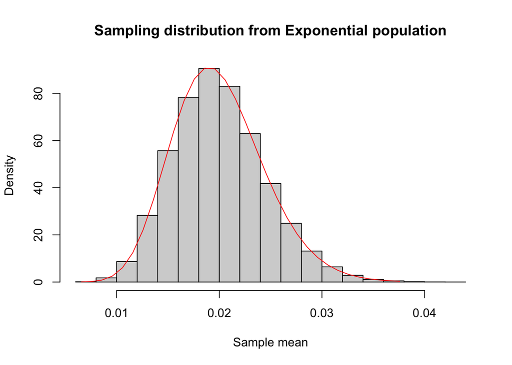

```r
# plot sampling distribution of sample means and add theoretical density curve
hist(x = x_bar, freq = FALSE, xlab = "Sample mean", main = "Sampling distribution from Exponential population")
x <- seq(from = mean(x_bar) - 3 * sd(x_bar), to = mean(x_bar) + 4 * sd(x_bar), by = 0.001)
lines(x = x, y = dgamma(x, shape = n, rate = n * lambda), col = "red")
```